# Homework 3

Ahmet Tabakoglu

06/06/2021

# Electricity Consumption of Turkey

In this project, hourly electricity consumption data of Turkey is gathered from [EPİAŞ](https://seffaflik.epias.com.tr/transparency/) website to analyze the properties of the data set and build a forecasting approach. The imported data set contains the data from 1st of January, 2016 till the 20th of May, 2021.

```r
consumption = read.table("C:/Users/AHMET/Desktop/gzt.txt", header = TRUE)
```

The graph of hourly consumption data and autocorrelation function are plotted below:

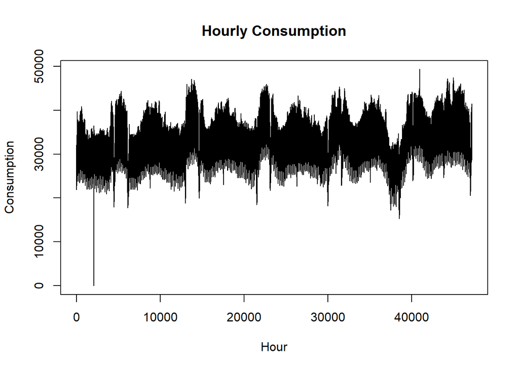

```r
ts.plot(consumption$Consumption, xlab="Hour", ylab="Consumption", main="Hourly Consumption")
```

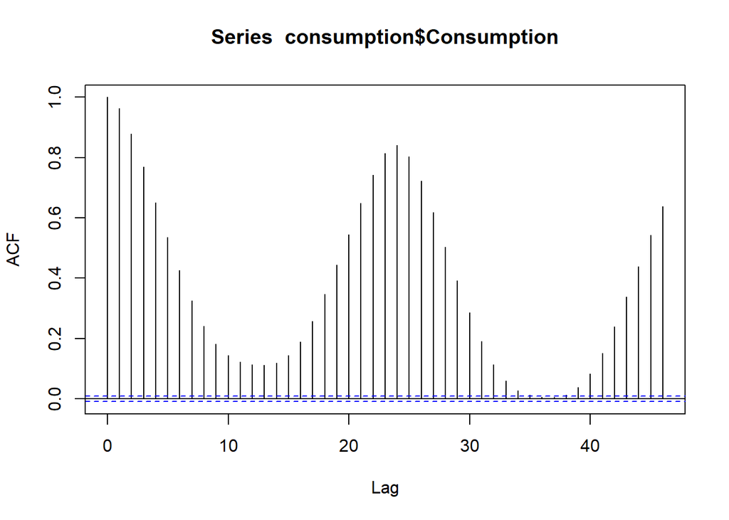

```r
acf(consumption$Consumption)
```

Looking at the hourly consumption graph, it can be initially stated that trend and seasonality properties are present. The data set has a slightly increasing trend and there are periodical ups and downs, which indicates that seasonality is observed. Another observation that can be made is that the autocorrelation between data points follow a similar path after every 24 hours, which points out that there may be hourly seasonality.

## Conversion into Time Series and Decomposition

### Monthly Time Series

The data set is converted into monthly time series data and hourly data is distributed to appropriate years by assuming that there are 30 days in each month. Then, the monthly time series data “monthlycons” is decomposed.

```r
monthlycons = ts(consumption$Consumption, freq=24*30*12, start = c(2016,1))
decmonthlycons = decompose(monthlycons, type = "multiplicative")
```

### Weekly Time Series

```r
weeklycons = ts(consumption$Consumption, freq=24*7*52, start = c(2016,1))
decweeklycons = decompose(monthlycons, type = "multiplicative")
```

### Daily Time Series

The data set is converted into daily time series data and hourly data is distributed to appropriate weeks where the first index number n indicates the nth week from the beginning of 2016. Then, the daily time series data “dailycons” is decomposed.

```r
dailycons = ts(consumption$Consumption, freq=24*7, start = c(1,1))
decdailycons = decompose(dailycons, type = "multiplicative")
```

### Hourly Time Series

The data set is converted into hourly time series data and hourly data is distributed to appropriate days where the first index number n indicates the nth day from the beginning of 2016. Then, the hourly time series data “hourlycons” is decomposed.

```r
hourlycons = ts(consumption$Consumption, freq=24, start = c(1,1))
dechourlycons = decompose(hourlycons, type = "multiplicative")
```

## Task 1

In this task, possible seasonality types of the hourly electricity consumption data set will be investigated at monthly, weekly, daily, and hourly levels.

### Monthly Seasonality

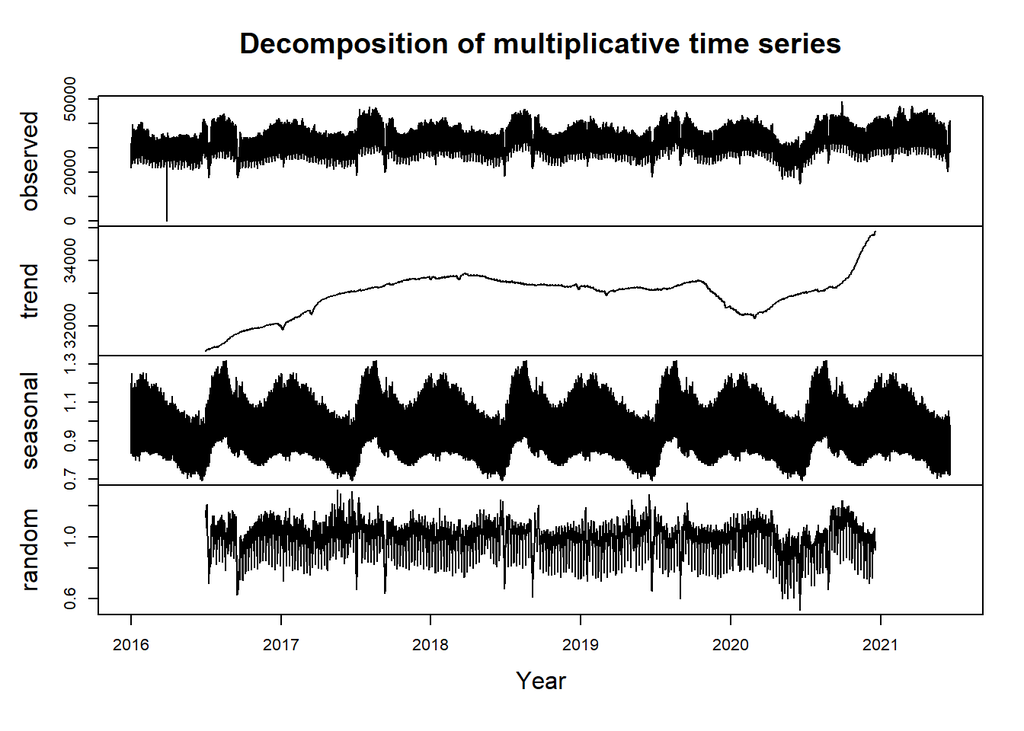

```r
plot(decmonthlycons, xlab = "Year")
```

The seasonal component of the monthly time series data shows that there are periodical ups and downs in each year. For instance, in every year, consumption level reaches its highest during the months that belong to summer as well as reaches its lowest during the months that belong to spring. Hence, it can be stated that there is a monthly seasonality. Besides, looking at the trend component, it can be said that there is an increasing trend in general.

### Weekly Seasonality

[figure not shown]

```r
plot(decweeklycons, xlab = "Year")
```

### Daily Seasonality

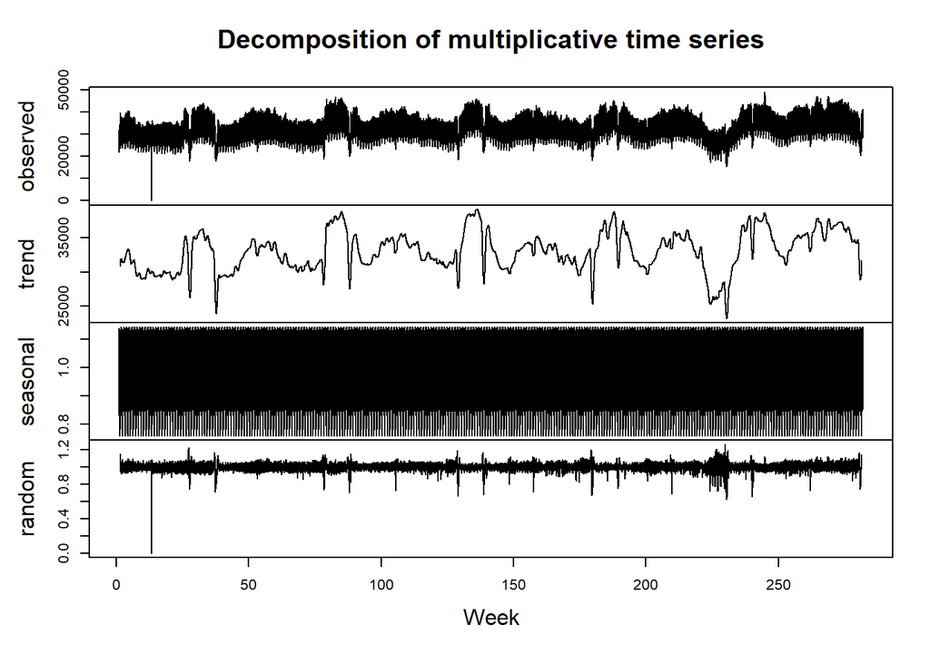

```r
plot(decdailycons, xlab = "Week")
```

Looking at the trend component of daily time series data, it can be stated that there is no apparent trend. Besides, since the seasonal component of this daily time series data has too many similar data points, it can be better to comment on the autocorrelation function graph of the seasonal component.

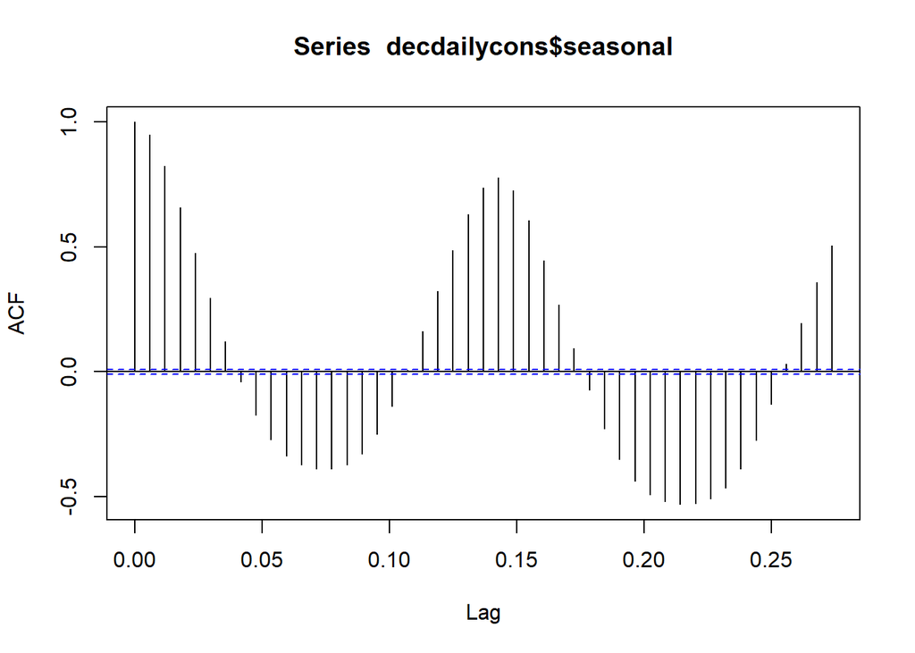

```r
acf(decdailycons$seasonal)
```

The autocorrelation function graph follows a sinusoidal path, hence it is periodic. Therefore, there is a daily seasonality.

### Hourly Seasonality

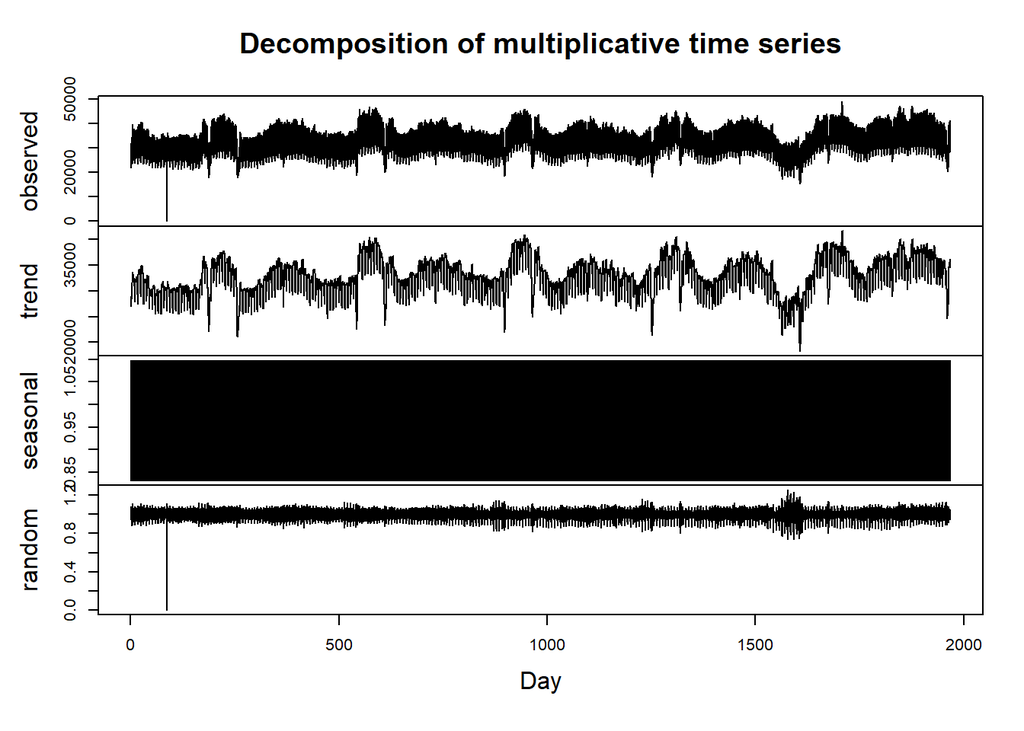

```r
plot(dechourlycons, xlab = "Day")
```

Looking at the trend component of hourly time series data, it can be stated that there is no apparent trend. Besides, since the seasonal component of this hourly time series data has too many similar data points, it can be better to comment on the autocorrelation function graph of the seasonal component.

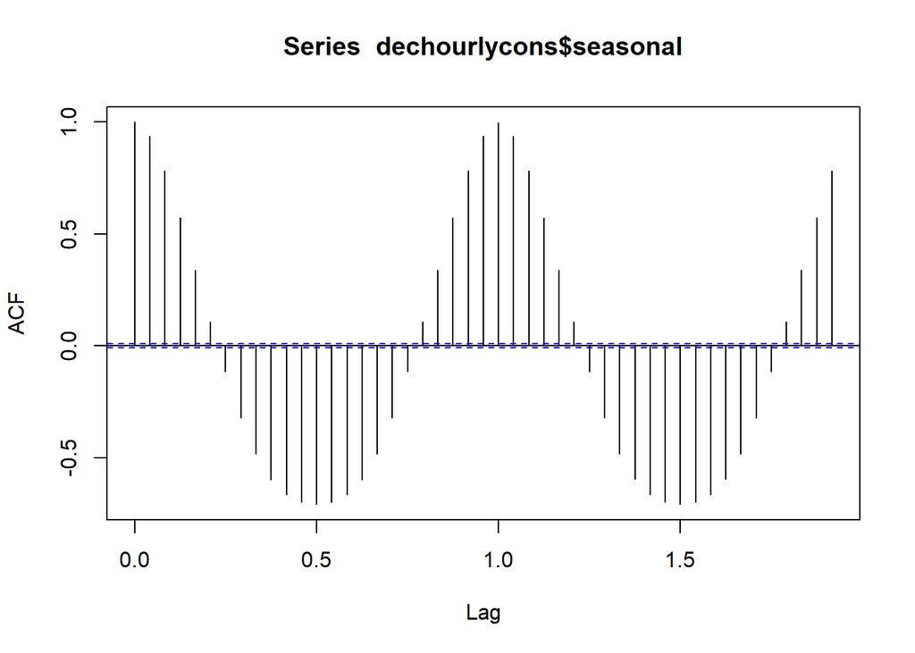

```r
acf(dechourlycons$seasonal)
```

The autocorrelation function graph follows a sinusoidal path, hence it is periodic. Therefore, there is a hourly seasonality.

## Task 2

In this task, it is given that the decided pattern is at every 168 hours. A frequency of 168 hours corresponds to the daily time series data formed and decomposed previously and commented on in the first task. The results after decomposition of daily time series data are given below:

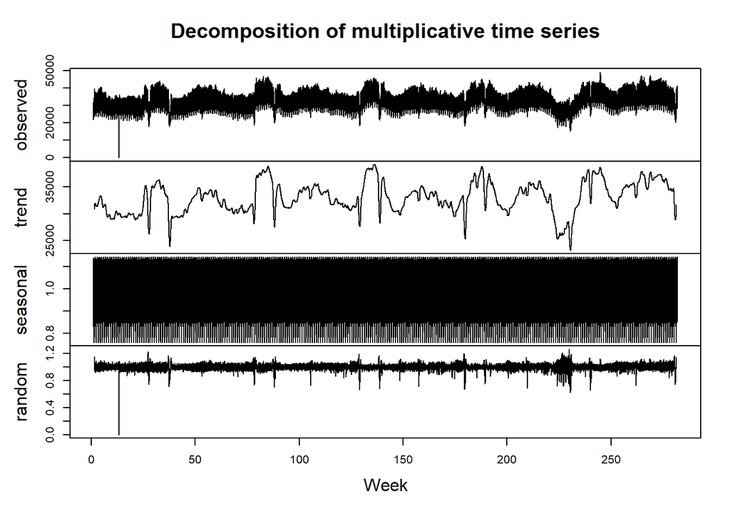

```r
plot(decdailycons, xlab = "Week")
```

As mentioned before, it can be stated that there is no apparent trend when the trend component is inspected. The plot of seasonal component above does not give enough information about the seasonality. Hence, it will be plotted and investigated separately.

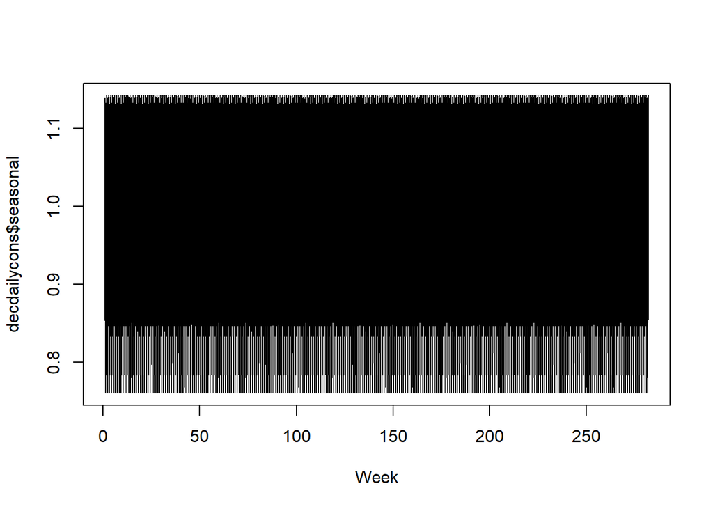

```r
ts.plot(decdailycons$seasonal, xlab = "Week")
```

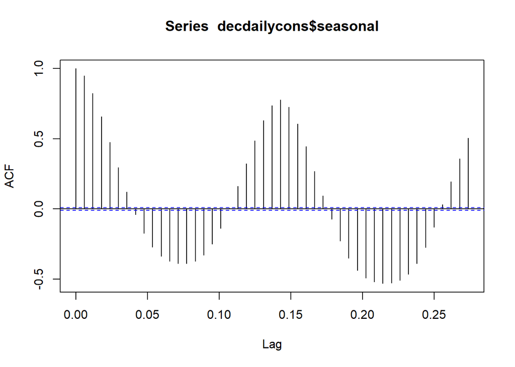

```r
acf(decdailycons$seasonal)
```

The plots above show that daily time series data follows a periodical pattern and therefore, it has daily seasonality.

## Task 3 & Task 4

In this task, it is requested to deseasonalize and detrend the daily time series data to form an appropriate MA model.

### Obtaining the Random Noise

Deseasonalizing:

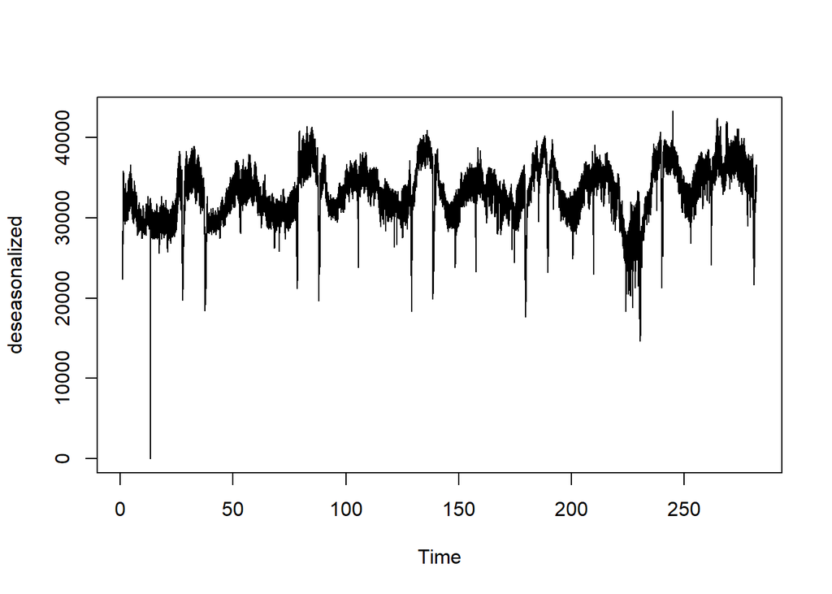

```r
deseasonalized = dailycons / decdailycons$seasonal
ts.plot(deseasonalized)
```

Detrending:

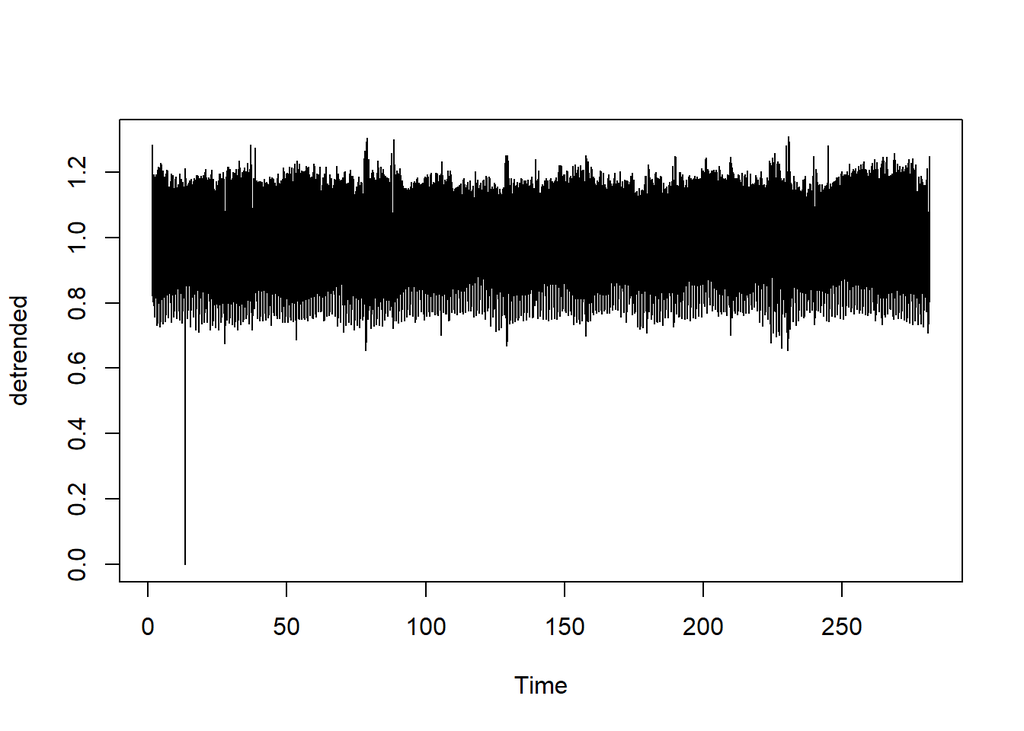

```r
detrended = dailycons / decdailycons$trend
ts.plot(detrended)
```

Both deseasonalizing and detrending to reach the random noise (can also be obtained by calling the random component of daily time series data):

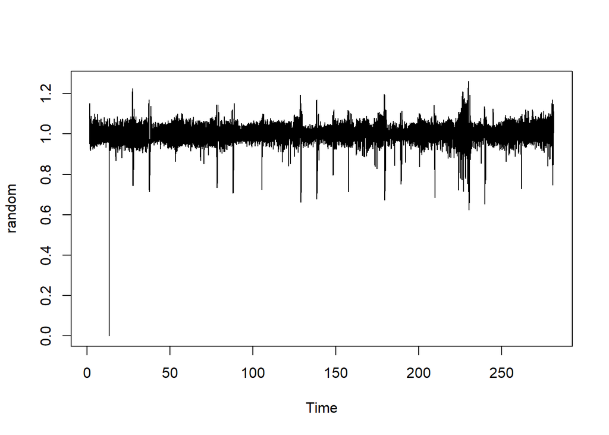

```r
random = deseasonalized / decdailycons$trend
random = na.omit(random)
ts.plot(random)
```

### Building an AR Model

Trying different AR models with different lag parameters to find the AR model with best AIC value:

```r
model = arima(random, order=c(1,0,0))
AIC(model)
```

```
## [1] -244416.2
```

```r
model = arima(random, order=c(2,0,0))
AIC(model)
```

```
## [1] -252067.8
```

```r
model = arima(random, order=c(3,0,0))
AIC(model)
```

```
## [1] -252169.8
```

```r
model = arima(random, order=c(4,0,0))
AIC(model)
```

```
## [1] -252188.2
```

```r
model = arima(random, order=c(5,0,0))
AIC(model)
```

```
## [1] -252201.7
```

```r
model = arima(random, order=c(6,0,0))
AIC(model)
```

```
## [1] -252201
```

The AIC value of the model with lag parameter p = 5 is -252201.7 whereas the model with lag parameter p = 6 is -252201 Since the AIC value increases after the model with lag parameter p = 5, the AR model with p = 5 is chosen.

```r
ARmodel = arima(random, order=c(5,0,0))
```

### Building an MA Model

Trying different MA models with different window parameters to find the MA model with best AIC value:

```r
model = arima(random, order=c(0,0,1))
AIC(model)
```

```
## [1] -206241
```

```r
model = arima(random, order=c(0,0,2))
AIC(model)
```

```
## [1] -228975.8
```

```r
model = arima(random, order=c(0,0,3))
AIC(model)
```

```
## [1] -240989.2
```

```r
model = arima(random, order=c(0,0,4))
AIC(model)
```

```
## [1] -246200.3
```

```r
model = arima(random, order=c(0,0,5))
AIC(model)
```

```
## [1] -249616.4
```

```r
model = arima(random, order=c(0,0,6))
AIC(model)
```

```
## [1] -250583.3
```

```r
model = arima(random, order=c(0,0,7))
AIC(model)
```

```
## [1] -251313.3
```

The AIC value of the model with window parameter q = 5 is -249616.4 whereas the model with window parameter q = 6 is -250583.3 Since amount of increase in the AIC value drops significantly after the model with window parameter q = 5, the AR model with q = 5 is chosen not to cause overfitting.

```r
MAmodel = arima(random, order=c(0,0,5))
```

## Task 5

### Comparison of the AR and MA models

AIC values of the AR and MA models built in Task 3 & Task 4 will be compared to find the better model.

AIC value of the AR model:

```r
AIC(ARmodel)
```

```
## [1] -252201.7
```

AIC value of the MA model:

```r
AIC(MAmodel)
```

```
## [1] -249616.4
```

Looking at the AIC values, it can be concluded that AR model with lag parameter p = 5 is better than the MA model with window parameter q = 5.

### Predictions Using the AR model

It is requested to reconstruct the model with the data until 23:00, 6th of May, 2021.

```r
newrandom = head(random, -(14*24-84))
newARmodel = arima(newrandom, order=c(5,0,0))
```

After constructing the new model using requested data set, the forecasting model is built for the next 14 days, until 23:00, 20th of May, 2021.

```r
library(forecast)
ARmodel_forecast = predict(newARmodel, n.ahead=14*24)$pred
last_trend = tail(decdailycons$trend[!is.na(decdailycons$trend)], 1)
seasonality = decdailycons$seasonal[46873:47208]
ARmodel_forecast = ARmodel_forecast*last_trend*seasonality
ARmodel_forecast
```

```
## Time Series:
## Start = 46789
## End = 47124
## Frequency = 1
##   [1] 30984.31 29450.90 28381.16 27647.52 27311.15 27147.27 27364.12 28837.71
##   [9] 32721.72 34979.98 35587.01 36063.02 34400.67 33949.27 35523.68 35519.87
##  [17] 35691.68 35726.86 35371.13 35270.18 35056.20 34396.51 33744.69 32440.87
##  [25] 30634.60 29095.39 27971.83 27204.16 26842.06 26566.55 26367.53 27013.21
##  [33] 29861.96 32030.68 33019.77 33629.75 32726.31 32978.06 33062.99 32717.33
##  [41] 32654.71 32905.88 33526.13 33859.75 33705.18 33091.71 32401.62 31046.06
##  [49] 29227.82 27659.86 26399.07 25692.61 25233.45 24821.70 24290.84 24058.81
##  [57] 24660.14 25901.66 27084.88 27865.88 27870.23 28268.68 28379.11 28430.93
##  [65] 28762.87 29553.52 30727.29 31542.95 31779.93 31326.96 30806.27 29585.35
##  [73] 28103.15 26660.24 25712.99 25126.50 24877.15 24804.84 25237.06 27113.95
##  [81] 31652.59 34233.22 34993.43 35581.62 34342.00 34904.80 35625.02 35535.18
```

[output cut: 31 more lines]

Finding the weighted mean absolute percentage error of the model for the predicted period:

```r
a = consumption$Consumption[46873:47208] #actual data
f = ARmodel_forecast #forecasted data
x_mape = abs(a-f)/a
a_sum = sum(a)
x_a_mape = a * x_mape
x_a_mape_sum = sum(x_a_mape)
wmape = x_a_mape_sum / a_sum
wmape
```

```
## [1] 0.1053815
```

As an overall performance measure, weighted mean absolute percentage error of the AR model constructed for the requested time interval is found to be 0.1053815

### Predictions Using the MA model

It is requested to reconstruct the model with the data until 23:00, 6th of May, 2021.

```r
newMAmodel = arima(newrandom, order=c(0,0,5))
```

After constructing the new model using requested data set, the forecasting model is built for the next 14 days, until 23:00, 20th of May, 2021.

```r
MAmodel_forecast = predict(newMAmodel, n.ahead=14*24)$pred
MAmodel_forecast = MAmodel_forecast*last_trend*seasonality
MAmodel_forecast
```

```
## Time Series:
## Start = 46789
## End = 47124
## Frequency = 1
##   [1] 30931.25 29378.82 28319.45 27490.48 27196.27 27016.84 27266.27 28763.37
##   [9] 32662.56 34936.75 35557.71 36043.74 34389.06 33942.27 35519.38 35517.48
##  [17] 35690.45 35726.31 35370.97 35270.22 35056.32 34396.66 33744.84 32440.99
##  [25] 30634.69 29095.46 27971.89 27204.21 26842.10 26566.58 26367.56 27013.24
##  [33] 29861.99 32030.71 33019.80 33629.78 32726.34 32978.08 33063.02 32717.36
##  [41] 32654.74 32905.90 33526.16 33859.78 33705.20 33091.74 32401.64 31046.09
##  [49] 29227.85 27659.88 26399.09 25692.63 25233.47 24821.72 24290.86 24058.83
##  [57] 24660.16 25901.68 27084.90 27865.90 27870.25 28268.70 28379.13 28430.95
##  [65] 28762.89 29553.55 30727.32 31542.98 31779.95 31326.98 30806.29 29585.37
##  [73] 28103.18 26660.27 25713.01 25126.52 24877.17 24804.86 25237.08 27113.97
##  [81] 31652.61 34233.24 34993.45 35581.65 34342.02 34904.83 35625.05 35535.21
```

[output cut: 31 more lines]

Finding the weighted mean absolute percentage error of the model for the predicted period:

```r
a = consumption$Consumption[46873:47208] #actual data
f = MAmodel_forecast #forecasted data
x_mape = abs(a-f)/a
a_sum = sum(a)
x_a_mape = a * x_mape
x_a_mape_sum = sum(x_a_mape)
wmape = x_a_mape_sum / a_sum
wmape
```

```
## [1] 0.1054693
```

As an overall performance measure, weighted mean absolute percentage error of the MA model constructed for the requested time interval is found to be 0.1054693

### Conclusion

The data from 00:00, 1st of January, 2016 until 23:00, 6th of May, 2021 is used as training set to construct new prediction models whose properties are already decided in Task 3 & Task 4. After reconstruction of each model, the predictions are made. Then, using the test set, which contains the data between 00:00, 7th of May, 2021 and 23:00, 20th of May, 2021, as an overall performance measure, weighted mean absolute percentage errors are calculated for each model. At the beginning of Task 5, the AR model was said to be better than the MA model by looking at AIC value of both models. After calculation of WMAPE values, it can be concluded that the AR model is still better since its WMAPE value is less than that of the MA model.